# Data Science Applications: Lecture 4

Data Reading/Writing in R (csv, rds, excel) and dplyr Part II

Josemari Feliciano

Spring 2025 - February 4

## Recap from last week

- Assignment Operator (`<-`)
- dplyr verbs: `filter()`, `arrange()`, `select()`
- In Operator (`%in%`)

## Homework 2

One of you consistently used `fill = "deepskyblue4"`, another used `theme_bw()`. **The point of ggplot is that it is highly customizable.** This is an example where I mixed and match customizations two of you used.

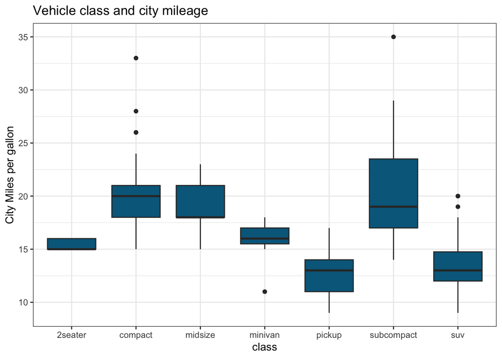

```r
ggplot(mpg, aes(x=class,y=cty))+
  geom_boxplot(fill = "deepskyblue4") +
  labs (title="Vehicle class and city mileage",
        y="City Miles per gallon") +
  theme_bw()
```

# Common Data Types To Import in R

1. Comma-separated values (.csv) files
2. RDS files (RDS: R Data Serialization) files - native R objects.
3. Excel (e.g., .xlsx) files

# Comma-separated values (.csv) files

When you open a csv file in Excel (in macOS/PC) or Numbers (in macOS), it will likely look nicely formatted in tabular format:

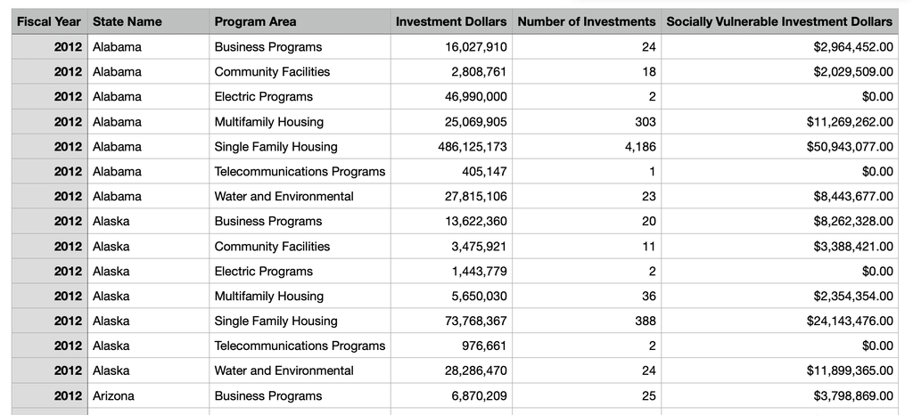

Figure 1. How .csv files look like when opened in macOS. The neat formatting should hold true in Excel programs in either PC or macOS.

# Comma-separated values (.csv) files

But when you open the csv file in basic text editors (e.g., PC’s Notepad, macOS’s TextEdit), the actual underlying data looks like the following:

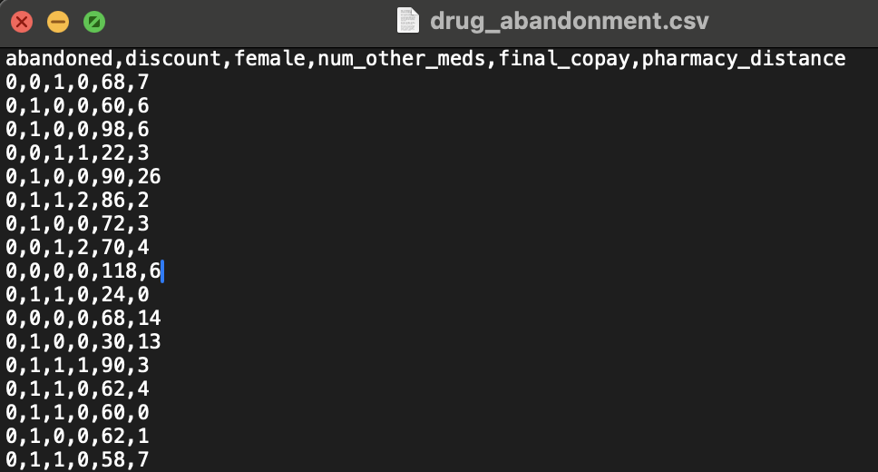

Figure 2. What a .csv file actually looks like using macOS’s TextEdit. This is what the underlying data looks like regardless of your operating system.

## Loading .csv files in R: Non-tidyverse way

read.csv() is part of base R, meaning it is built in within R. So you can run it without loading any packages (e.g., library(tidyverse))

```r
your_data_name <- read.csv("FileLocation/filename.csv")
```

**Note 1:** “FileLocation/filename.csv” is commonly referred to as file path. Do not worry about this for now. I will later recommend a best practice to simply this for you.

**Note 2:** If you are using R in Windows, R forces you to use the forward slash (/) for path instead of the backward slash (\) used in Windows for file paths.

## Loading .csv files in R: tidyverse (readr) way

read_csv() is part of readr, a core tidyverse package. So when you load the tidyverse package (i.e., library(tidyverse)), you can use functions from readr.

```r
library(tidyverse)
your_data_name <- read_csv("FileLocation/filename.csv")
```

**A key benefit of using read_csv() over read.csv()?** Performance. When working with extremely large data sets, read.csv() may take few minutes to load data, while read_csv() may take only take several seconds to load the same large dataset.

**Which one should you use for this course?** You are may use `read_csv()` or `read.csv()` for your class work. But generally, `read_csv()` is preferred by data scientists for performance and other reasons beyond the scope of this course.

## Best practice (recommended) set up - 1/3

**Step 1:**

After you create your Quarto Notebook for data analysis (e.g., AnalysisQuartoNotebook.qmd), create a **data** folder within the same location of your Quarto notebook where you will place any files you will read for data analysis and exploration.

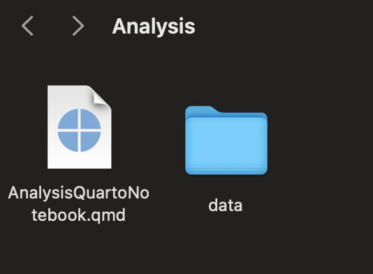

Figure 3. Recommended set-up when working with quarto notebook and many files you need to read. Screenshot of set-up in macOS.

## Best practice (recommended) set up - 2/3

**Step 2:**

Place data sets (e.g., csv, excel files) you will need to analyze inside the **data** folder you created. For this example, I will include the **drug_abandonment.csv** file I uploaded under the Week 4 folder in Canvas.

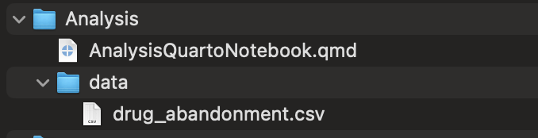

Figure 4. Place file(s) you will load inside the data folder. This is a screenshot from macOS.

## Best practice (recommended) set up - 3/3

**Step 3:**

Within your quarto document, load the tidyverse and use `read_csv("data/{file_name}.csv")`, where **{file_name}** is the name of your CSV file.

In the example below, `"data/drug_abandonment.csv"` tells R to look for the file within the **data** folder next to your quarto document while it tells R to load the `drug_abandonment.csv` file from that **data** folder.

```r
library(tidyverse)
# Creates abandonment_data in R envt from drug_abandonment.csv
abandonment_data <- read_csv("data/drug_abandonment.csv")
```

## Creating csv files

Data analysts and data scientists are often data providers to many data stakeholders. This often requires you to manipulate an underlying data set and then create a data set out of the resulting data for those people.

To create csv files, you may use: `write_csv({data_environment}, "{filename.csv}")` where `{data_environment}` is the data name from the R environment you wish to create a csv out of and `{filename.csv}` is the file name of the csv. **The csv will be created within the same folder where your Quarto document resides.**

Example:

```r
library(tidyverse)
library(palmerpenguins)
data("penguins")
# creates adelie_excluded
adelie_excluded <- penguins |>
  filter(species != "Adelie")

# Creates AdelieExcludedData.csv from adelie_excluded
write_csv(adelie_excluded, "AdelieExcludedData.csv")
```

## Reading and saving RDS files

You may use read_rds() and write_rds() using the same structure or code format used for the csv counterparts (this time, the file extension is .rds).

To load RDS files (assuming you followed recommended set up):

```r
# creates storms_data from storms.rds placed within data folder
storms_data <- read_rds("data/storms.rds")
```

To save RDS files:

```r
# creates chinstrap_excluded
chinstrap_excluded <- penguins |>
  filter(species != "Chinstrap")

# Creates ChinstapExcludedData.rds from chinstrap_excluded
write_rds(chinstrap_excluded, "ChinstapExcludedData.rds")
```

Again, where can you find ‘ChinstapExcludedData.rds’ after it is created?

## Cases where creating/loading/sharing RDS might be superior

If you know the person you’re sharing data with uses R, RDS is likely the superior option over CSV files.

RDS version of the same data will load much faster than the CSV version since RDS is an R native data file.

An advantage of RDS is it preserves data types.

## Working with excel files (e.g., xlsx)

readxl is the primary package used by data scientists to read excel files into R.

When you installed tidyverse in R/RStudio, readxl is also installed. However, the readxl package is not loaded when you run library(tidyverse) since it is not part of the ‘core’ tidyverse packages, so you will need to load it separately.

Below is an example of an excel sheet with one sheet.

[figure not shown]

Figure 5. An example Excel (students.xlsx) file where there is only one sheet.

### Reading excel file with one sheet

read_excel() from readxl is the function or tool you will need for reading excel files.

If your data only has one sheet, you may run the following the load the data into R:

```r
library(readxl)
student_data <- read_excel("data/students.xlsx")
head(student_data)
```

```
## # A tibble: 6 × 5
##   `Student ID` `Full Name`      favourite.food     mealPlan            AGE
##          <dbl> <chr>            <chr>              <chr>               <chr>
## 1            1 Sunil Huffmann   Strawberry yoghurt Lunch only          4.0
## 2            2 Barclay Lynn     French fries       Lunch only          5.0
## 3            3 Jayendra Lyne    N/A                Breakfast and lunch 7.0
## 4            4 Leon Rossini     Anchovies          Lunch only          <NA>
## 5            5 Chidiegwu Dunkel Pizza              Breakfast and lunch five
## 6            6 Güvenç Attila    Ice cream          Lunch only          6.0
```

### Reading excel file with multiple sheets

[figure not shown]

Figure 6. An example Excel (penguins.xlsx) file where there are multiple sheets.

### Reading excel file with multiple sheets

Again, we will use read_excel() from the readxl package. To specify the sheet you want to load, you need to include `sheet = "{Sheet Name}"` inside read_excel.

This time, we will include `sheet = "Torgersen Island"` as an argument to specifically pick the Torgersen Island sheet:

```r
library(readxl)
# Reads the data from sheet labelled Torgersen Island
torgersen_data <- read_excel("data/penguins.xlsx",
                             sheet = "Torgersen Island")
head(torgersen_data)
```

```
## # A tibble: 6 × 8
##   species island    bill_length_mm bill_depth_mm flipper_length_mm body_mass_g
##   <chr>   <chr>     <chr>          <chr>         <chr>             <chr>
## 1 Adelie  Torgersen 39.1           18.7          181.0             3750.0
## 2 Adelie  Torgersen 39.5           17.4          186.0             3800.0
## 3 Adelie  Torgersen 40.3           18.0          195.0             3250.0
## 4 Adelie  Torgersen NA             NA            NA                NA
## 5 Adelie  Torgersen 36.7           19.3          193.0             3450.0
## 6 Adelie  Torgersen 39.3           20.6          190.0             3650.0
## # ℹ 2 more variables: sex <chr>, year <dbl>
```

### Writing excel files

writexl is the package you need to write excel files. write_xlsx() is the function you will need to use to write excel (.xlsx) files. Again, write_xlsx() follows the same format/arguments used for write_csv() and write_rds().

Note: You will need to install writexl by yourself before using it! **I will not ask you to write excel files for this course**

```r
# if writexl is not installed:
# run install.packages("writexl") in R console first
library(writexl)

# creates gentoo_excluded
gentoo_excluded <- penguins |>
  filter(species != "Gentoo")

# Creates GentooExcludedData.xlsx from gentoo_excluded
write_xlsx(gentoo_excluded, "GentooExcludedData.xlsx")
```

## We will do a hands-on demo on file reading and go over other dplyr verbs we failed to cover last week.

## Download Data312Exercise4.qmd from Canvas and open the Quarto Document in Canvas.